# ip_week12

# Defining the Question

## 1. Specifying the Question

### Which individuals are most likely to click on an online cryptography course advertisement?

## 2. Metric for success

### Come up with an analysis that will make our customer identify individuals who are likely to click on her cryptography course.

## 3. Understanding the Context

### A Kenyan entrepreneur has created an online cryptography course and would want to advertise it on her blog. She currently targets audiences originating from various countries. In the past, she ran ads to advertise a related course on the same blog and collected data in the process. She would now like to employ your services as a Data Science Consultant to help her identify which individuals are most likely to click on her ads.

## 4. Experimental Design taken

1. Data Exploration
2. Data Cleaning
3. Univariate Analysis
4. Bivariate Analysis
5. Conclusion

## 5. Appropriateness data

### Our data was readily available as it was provided by the client…Thus data collection was not needed.

# 1. Data Exploration

## Loading the necessary packages

```r
library("data.table")
advert <- read.csv("advertising.csv")

##Previewing the first 6 rows of dataset

head(advert)
```

```
##   Daily.Time.Spent.on.Site Age Area.Income Daily.Internet.Usage
## 1                    68.95  35    61833.90               256.09
## 2                    80.23  31    68441.85               193.77
## 3                    69.47  26    59785.94               236.50
## 4                    74.15  29    54806.18               245.89
## 5                    68.37  35    73889.99               225.58
## 6                    59.99  23    59761.56               226.74
##                           Ad.Topic.Line           City Male    Country
## 1    Cloned 5thgeneration orchestration    Wrightburgh    0    Tunisia
## 2    Monitored national standardization      West Jodi    1      Nauru
## 3      Organic bottom-line service-desk       Davidton    0 San Marino
## 4 Triple-buffered reciprocal time-frame West Terrifurt    1      Italy
## 5         Robust logistical utilization   South Manuel    0    Iceland
## 6       Sharable client-driven software      Jamieberg    1     Norway
##             Timestamp Clicked.on.Ad
## 1 2016-03-27 00:53:11             0
## 2 2016-04-04 01:39:02             0
## 3 2016-03-13 20:35:42             0
## 4 2016-01-10 02:31:19             0
## 5 2016-06-03 03:36:18             0
## 6 2016-05-19 14:30:17             0
```

```r
##Previewing the last 6 rows of dataset

tail(advert)
```

```
##      Daily.Time.Spent.on.Site Age Area.Income Daily.Internet.Usage
## 995                     43.70  28    63126.96               173.01
## 996                     72.97  30    71384.57               208.58
## 997                     51.30  45    67782.17               134.42
## 998                     51.63  51    42415.72               120.37
## 999                     55.55  19    41920.79               187.95
## 1000                    45.01  26    29875.80               178.35
##                             Ad.Topic.Line          City Male
## 995         Front-line bifurcated ability  Nicholasland    0
## 996         Fundamental modular algorithm     Duffystad    1
## 997       Grass-roots cohesive monitoring   New Darlene    1
## 998          Expanded intangible solution South Jessica    1
## 999  Proactive bandwidth-monitored policy   West Steven    0
## 1000      Virtual 5thgeneration emulation   Ronniemouth    0
##                     Country           Timestamp Clicked.on.Ad
## 995                 Mayotte 2016-04-04 03:57:48             1
## 996                 Lebanon 2016-02-11 21:49:00             1
## 997  Bosnia and Herzegovina 2016-04-22 02:07:01             1
## 998                Mongolia 2016-02-01 17:24:57             1
## 999               Guatemala 2016-03-24 02:35:54             0
## 1000                 Brazil 2016-06-03 21:43:21             1
```

```r
##Basic structure of the data
str(advert)
```

```
## 'data.frame':    1000 obs. of  10 variables:
##  $ Daily.Time.Spent.on.Site: num  69 80.2 69.5 74.2 68.4 ...
##  $ Age                     : int  35 31 26 29 35 23 33 48 30 20 ...
##  $ Area.Income             : num  61834 68442 59786 54806 73890 ...
##  $ Daily.Internet.Usage    : num  256 194 236 246 226 ...
##  $ Ad.Topic.Line           : chr  "Cloned 5thgeneration orchestration" "Monitored national standardization" "Organic bottom-line service-desk" "Triple-buffered reciprocal time-frame" ...
##  $ City                    : chr  "Wrightburgh" "West Jodi" "Davidton" "West Terrifurt" ...
##  $ Male                    : int  0 1 0 1 0 1 0 1 1 1 ...
##  $ Country                 : chr  "Tunisia" "Nauru" "San Marino" "Italy" ...
##  $ Timestamp               : chr  "2016-03-27 00:53:11" "2016-04-04 01:39:02" "2016-03-13 20:35:42" "2016-01-10 02:31:19" ...
##  $ Clicked.on.Ad           : int  0 0 0 0 0 0 0 1 0 0 ...
```

# 2. Data Cleaning

## Tidying the dataset the dataset

```r
# Identifying duplicates
advert[duplicated(advert), ]
```

```
##  [1] Daily.Time.Spent.on.Site Age                      Area.Income
##  [4] Daily.Internet.Usage     Ad.Topic.Line            City
##  [7] Male                     Country                  Timestamp
## [10] Clicked.on.Ad
## <0 rows> (or 0-length row.names)
```

```r
##There are no duplicates in this dataset.

## Identifying missing data
length(which(!is.na(advert)))
```

```
## [1] 10000
```

```r
#
##checking the missing data
colSums(is.na(advert))
```

```
## Daily.Time.Spent.on.Site                      Age              Area.Income
##                        0                        0                        0
##     Daily.Internet.Usage            Ad.Topic.Line                     City
##                        0                        0                        0
##                     Male                  Country                Timestamp
##                        0                        0                        0
##            Clicked.on.Ad
##                        0
```

```r
##There is no missing data
```

## Checking for outliers

```r
boxplot.stats(advert$`Daily Time Spent on Site`)$out
```

[output not shown]

```r
boxplot.stats(advert$Age)$out
```

```
## integer(0)
```

```r
boxplot.stats(advert$`Area Income`)$out
```

[output not shown]

```r
boxplot.stats(advert$`Daily Internet Usage`)$out
```

[output not shown]

```r
boxplot.stats(advert$`Clicked on Ad`)$out
```

[output not shown]

```r
numeric_cols <- unlist(lapply(advert, is.numeric))
numeric_cols
```

```
## Daily.Time.Spent.on.Site                      Age              Area.Income
##                     TRUE                     TRUE                     TRUE
##     Daily.Internet.Usage            Ad.Topic.Line                     City
##                     TRUE                    FALSE                    FALSE
##                     Male                  Country                Timestamp
##                     TRUE                    FALSE                    FALSE
##            Clicked.on.Ad
##                     TRUE
```

[figure not shown]

```r
boxplot(numeric_cols)
```

## checking for anomalies

Anomalies are inconsistencies in the data

```r
###Checking the number of unique values in each column
lengths(lapply(advert, unique))
```

```
## Daily.Time.Spent.on.Site                      Age              Area.Income
##                      900                       43                     1000
##     Daily.Internet.Usage            Ad.Topic.Line                     City
##                      966                     1000                      969
##                     Male                  Country                Timestamp
##                        2                      237                     1000
##            Clicked.on.Ad
##                        2
```

```r
str(advert)
```

```
## 'data.frame':    1000 obs. of  10 variables:
##  $ Daily.Time.Spent.on.Site: num  69 80.2 69.5 74.2 68.4 ...
##  $ Age                     : int  35 31 26 29 35 23 33 48 30 20 ...
##  $ Area.Income             : num  61834 68442 59786 54806 73890 ...
##  $ Daily.Internet.Usage    : num  256 194 236 246 226 ...
##  $ Ad.Topic.Line           : chr  "Cloned 5thgeneration orchestration" "Monitored national standardization" "Organic bottom-line service-desk" "Triple-buffered reciprocal time-frame" ...
##  $ City                    : chr  "Wrightburgh" "West Jodi" "Davidton" "West Terrifurt" ...
##  $ Male                    : int  0 1 0 1 0 1 0 1 1 1 ...
##  $ Country                 : chr  "Tunisia" "Nauru" "San Marino" "Italy" ...
##  $ Timestamp               : chr  "2016-03-27 00:53:11" "2016-04-04 01:39:02" "2016-03-13 20:35:42" "2016-01-10 02:31:19" ...
##  $ Clicked.on.Ad           : int  0 0 0 0 0 0 0 1 0 0 ...
```

# 3. Univariate Analysis

## checking the means of all our numerical values

```r
# Summary of the dataset
summary(advert)
```

```
##  Daily.Time.Spent.on.Site      Age         Area.Income    Daily.Internet.Usage
##  Min.   :32.60            Min.   :19.00   Min.   :13996   Min.   :104.8
##  1st Qu.:51.36            1st Qu.:29.00   1st Qu.:47032   1st Qu.:138.8
##  Median :68.22            Median :35.00   Median :57012   Median :183.1
##  Mean   :65.00            Mean   :36.01   Mean   :55000   Mean   :180.0
##  3rd Qu.:78.55            3rd Qu.:42.00   3rd Qu.:65471   3rd Qu.:218.8
##  Max.   :91.43            Max.   :61.00   Max.   :79485   Max.   :270.0
##  Ad.Topic.Line          City                Male         Country
##  Length:1000        Length:1000        Min.   :0.000   Length:1000
##  Class :character   Class :character   1st Qu.:0.000   Class :character
##  Mode  :character   Mode  :character   Median :0.000   Mode  :character
##                                        Mean   :0.481
##                                        3rd Qu.:1.000
##                                        Max.   :1.000
##   Timestamp         Clicked.on.Ad
##  Length:1000        Min.   :0.0
##  Class :character   1st Qu.:0.0
##  Mode  :character   Median :0.5
##                     Mean   :0.5
##                     3rd Qu.:1.0
##                     Max.   :1.0
```

```r
# Getting the time period of the data
range(advert$Timestamp)
```

```
## [1] "2016-01-01 02:52:10" "2016-07-24 00:22:16"
```

### Getting variance and std.deviation of Daily time spent on site

```r
advert.daily.variance <- var(advert$Daily.Time.Spent.on.Site)
advert.daily.variance
```

```
## [1] 251.3371
```

```r
#checking the datatypes on the columns
sapply(advert, class)
```

```
## Daily.Time.Spent.on.Site                      Age              Area.Income
##                "numeric"                "integer"                "numeric"
##     Daily.Internet.Usage            Ad.Topic.Line                     City
##                "numeric"              "character"              "character"
##                     Male                  Country                Timestamp
##                "integer"              "character"              "character"
##            Clicked.on.Ad
##                "integer"
```

```r
# Getting variance and std.deviation of Area Income

var(advert$Area.Income)
```

```
## [1] 179952406
```

```r
##the timestamp has  a wrong data type so we will need to convert it to datetime
advert$Timestamp <- as.POSIXct(advert$Timestamp, "%Y-%m-%d %H:%M:%S",tz = "GMT")

### Checking if change has been effected
sapply(advert, class)
```

```
## $Daily.Time.Spent.on.Site
## [1] "numeric"
##
## $Age
## [1] "integer"
##
## $Area.Income
## [1] "numeric"
##
## $Daily.Internet.Usage
## [1] "numeric"
##
## $Ad.Topic.Line
## [1] "character"
##
## $City
## [1] "character"
##
## $Male
## [1] "integer"
##
## $Country
## [1] "character"
##
## $Timestamp
## [1] "POSIXct" "POSIXt"
##
## $Clicked.on.Ad
## [1] "integer"
```

```r
summary(advert)
```

```
##  Daily.Time.Spent.on.Site      Age         Area.Income    Daily.Internet.Usage
##  Min.   :32.60            Min.   :19.00   Min.   :13996   Min.   :104.8
##  1st Qu.:51.36            1st Qu.:29.00   1st Qu.:47032   1st Qu.:138.8
##  Median :68.22            Median :35.00   Median :57012   Median :183.1
##  Mean   :65.00            Mean   :36.01   Mean   :55000   Mean   :180.0
##  3rd Qu.:78.55            3rd Qu.:42.00   3rd Qu.:65471   3rd Qu.:218.8
##  Max.   :91.43            Max.   :61.00   Max.   :79485   Max.   :270.0
##  Ad.Topic.Line          City                Male         Country
##  Length:1000        Length:1000        Min.   :0.000   Length:1000
##  Class :character   Class :character   1st Qu.:0.000   Class :character
##  Mode  :character   Mode  :character   Median :0.000   Mode  :character
##                                        Mean   :0.481
##                                        3rd Qu.:1.000
##                                        Max.   :1.000
##    Timestamp                   Clicked.on.Ad
##  Min.   :2016-01-01 02:52:10   Min.   :0.0
##  1st Qu.:2016-02-18 02:55:42   1st Qu.:0.0
##  Median :2016-04-07 17:27:29   Median :0.5
##  Mean   :2016-04-10 10:34:06   Mean   :0.5
##  3rd Qu.:2016-05-31 03:18:14   3rd Qu.:1.0
##  Max.   :2016-07-24 00:22:16   Max.   :1.0
```

### Getting variance and std.deviation of Daily time spent on site

```r
var(advert$Daily.Time.Spent.on.Site)
```

```
## [1] 251.3371
```

```r
sd(advert$Daily.Time.Spent.on.Site)
```

```
## [1] 15.85361
```

```r
# Getting variance and std.deviation of Area Income

var(advert$Area.Income)
```

```
## [1] 179952406
```

```r
sd(advert$Area.Income)
```

```
## [1] 13414.63
```

```r
# Getting variance and std.deviation of Daily Internet Usage
sd(advert$Daily.Internet.Usage)
```

```
## [1] 43.90234
```

```r
var(advert$Daily.Internet.Usage)
```

```
## [1] 1927.415
```

```r
# Function to get mode
mode <- function(v){
  uniq <- unique(as.integer(v))
  uniq[which.max(tabulate(match(as.integer(v), uniq)))]
}
```

```r
# Mode of daily time spent on site
daily.site <- mode(advert$Daily.Time.Spent.on.Site)
daily.site
```

```
## [1] 78
```

Alot of people spend 78 minutes browsing on the site.

```r
# Getting the mode of the age
age.mode <- mode(advert$Age)
age.mode
```

```
## [1] 31
```

Most people on the site are age 31

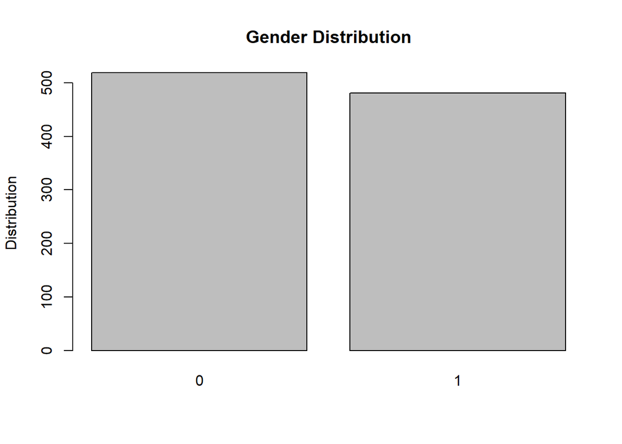

```r
# Distribution of the genders
gender <- advert$Male
gen <- table(gender)
barplot(gen, main = "Gender Distribution", ylab = "Distribution")
```

Females browsing on the site are more than males by a small percantage.

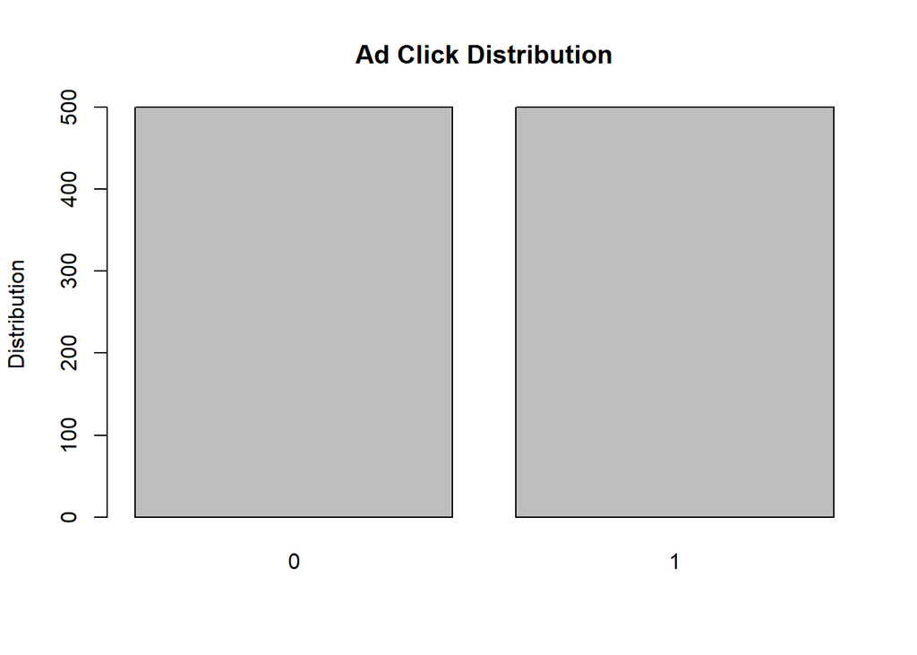

```r
# Distribution of whether one clicked or did not click on an ad
click <- advert$Clicked.on.Ad
clicked <- table(click)
barplot(clicked, main = "Ad Click Distribution", ylab = "Distribution")
```

There is a 50% chance that someone will click on the add while browsing the internet.

```r
area_income_mode<- mode((advert$Area.Income))
area_income_mode
```

```
## [1] 51636
```

```r
internetusage_mode<- mode(advert$Daily.Internet.Usage)
internetusage_mode
```

```
## [1] 231
```

### range

```r
range(advert$Age)
```

```
## [1] 19 61
```

people browsing the internet are between ages 19 an 61.

```r
# ad clicked per country
country_ad <- table(advert$Country, advert$Clicked.on.Ad)
names(dimnames(country_ad)) <- c("Country", "Clicked on Ad")
country_ad
```

```
##                                                      Clicked on Ad
## Country                                               0 1
##   Afghanistan                                         3 5
##   Albania                                             3 4
##   Algeria                                             3 3
##   American Samoa                                      2 3
##   Andorra                                             0 2
##   Angola                                              3 1
##   Anguilla                                            3 3
##   Antarctica (the territory South of 60 deg S)        1 2
##   Antigua and Barbuda                                 1 4
##   Argentina                                           1 1
##   Armenia                                             2 1
##   Aruba                                               1 0
##   Australia                                           1 7
##   Austria                                             4 1
##   Azerbaijan                                          2 1
##   Bahamas                                             3 4
##   Bahrain                                             3 2
##   Bangladesh                                          2 2
##   Barbados                                            3 2
##   Belarus                                             3 3
##   Belgium                                             3 2
##   Belize                                              2 3
##   Benin                                               1 1
##   Bermuda                                             1 0
##   Bhutan                                              1 1
##   Bolivia                                             6 0
##   Bosnia and Herzegovina                              4 3
##   Bouvet Island (Bouvetoya)                           3 2
##   Brazil                                              2 3
##   British Indian Ocean Territory (Chagos Archipelago) 0 1
##   British Virgin Islands                              2 1
##   Brunei Darussalam                                   3 2
##   Bulgaria                                            2 4
##   Burkina Faso                                        3 1
##   Burundi                                             5 2
##   Cambodia                                            5 2
##   Cameroon                                            5 0
##   Canada                                              2 3
```

[output cut: 184 more lines]

```
##   United Arab Emirates                                3 3
##   United Kingdom                                      1 2
##   United States Minor Outlying Islands                2 2
##   United States of America                            2 3
##   United States Virgin Islands                        2 2
##   Uruguay                                             4 1
##   Uzbekistan                                          1 1
##   Vanuatu                                             5 1
##   Venezuela                                           4 3
##   Vietnam                                             1 2
##   Wallis and Futuna                                   3 1
##   Western Sahara                                      3 4
##   Yemen                                               1 2
##   Zambia                                              1 3
##   Zimbabwe                                            2 4
```

People from Australia, Ethopia, turkey and Liechtenstein had highest click on the ad, Liechtenstein and ethopia had all people click on the ad.

# 4. Bivariate Analysis

```r
# Assigning the age column to the variable age
# ---
#
age <- advert$Age
```

```r
# Assigning the Clicked.on.Ad column to the variable adclicked
# ---
#
timespent<- advert$ Daily.Time.Spent.on.Site
```

### Using the cov() function to determine the covariance

```r
#
cov(age, timespent)
```

```
## [1] -46.17415
```

```r
# Using the cor() function to determine the correlation
# ---
#
cor(age, timespent)
```

```
## [1] -0.3315133
```

```r
# Getting correlation of the continuous variables
cor(advert[,unlist(lapply(advert, is.numeric))])
```

```
##                          Daily.Time.Spent.on.Site         Age  Area.Income
## Daily.Time.Spent.on.Site               1.00000000 -0.33151334  0.310954413
## Age                                   -0.33151334  1.00000000 -0.182604955
## Area.Income                            0.31095441 -0.18260496  1.000000000
## Daily.Internet.Usage                   0.51865848 -0.36720856  0.337495533
## Male                                  -0.01895085 -0.02104406  0.001322359
## Clicked.on.Ad                         -0.74811656  0.49253127 -0.476254628
##                          Daily.Internet.Usage         Male Clicked.on.Ad
## Daily.Time.Spent.on.Site           0.51865848 -0.018950855   -0.74811656
## Age                               -0.36720856 -0.021044064    0.49253127
## Area.Income                        0.33749553  0.001322359   -0.47625463
## Daily.Internet.Usage               1.00000000  0.028012326   -0.78653918
## Male                               0.02801233  1.000000000   -0.03802747
## Clicked.on.Ad                     -0.78653918 -0.038027466    1.00000000
```

### Correlation plot package

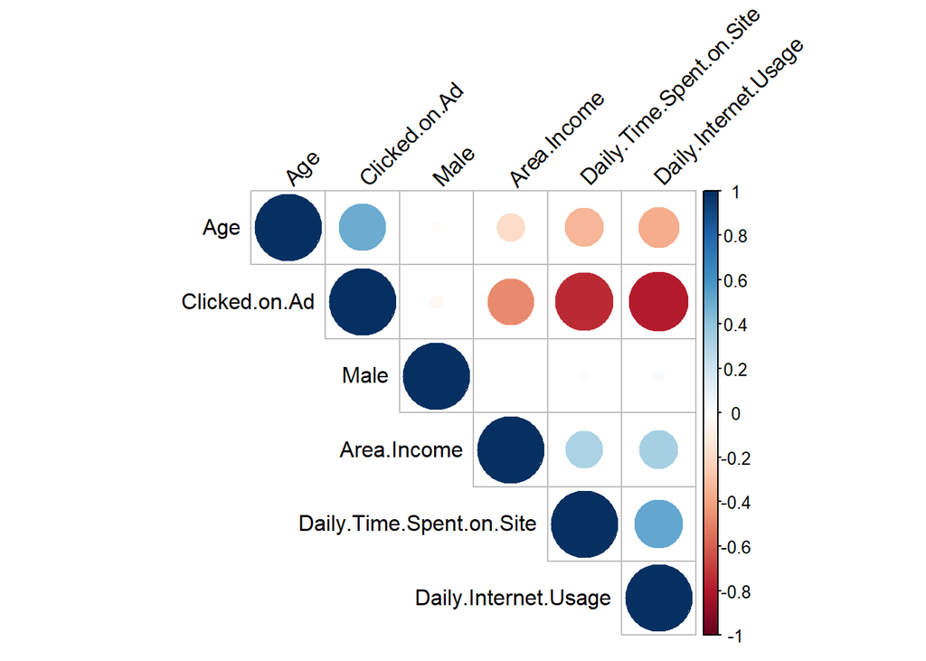

```r
#install.packages("corrplot")
library('corrplot')
#Plotting a correlation matrix plot
corrplot(cor(advert[,unlist(lapply(advert, is.numeric))]), type = "upper", order = "hclust", tl.col = "black", tl.srt = 45)
```

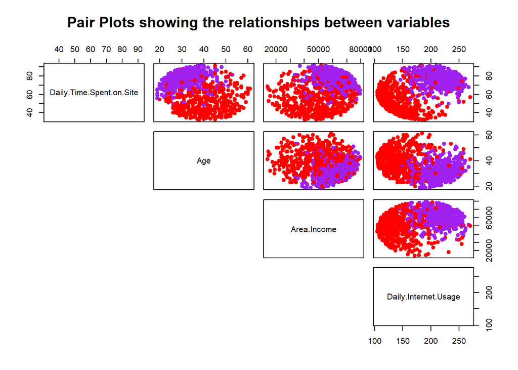

```r
#install.packages("tidyverse")

# Grouping the data by whether one clicked an ad or not
group <- NA
group[advert$Clicked.on.Ad == 1] <- 1
group[advert$Clicked.on.Ad == 0] <- 2

# Plotting a pair plot
pairs(advert[,1:4], pch = 19, lower.panel = NULL,
      main="Pair Plots showing the relationships between variables",
      col = c("red", "purple")[group])
```

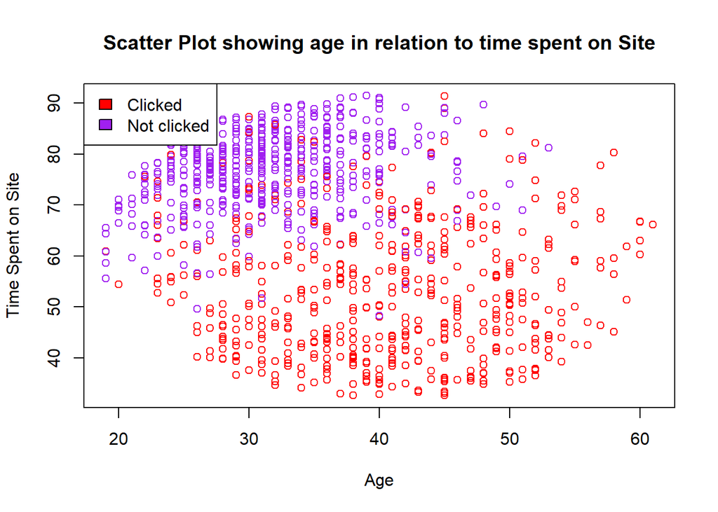

```r
# Grouping by gender
group1 <- NA
group1[advert$Male == 1] <- 1
group1[advert$Male == 0] <- 2

# Setting the x and y variables
x <- advert$Age
y <- advert$Daily.Time.Spent.on.Site

# Scatter plot
plot(x, y, xlab = "Age", ylab = "Time Spent on Site", col = c("red", "purple")[group],
     main="Scatter Plot showing age in relation to time spent on Site")
legend("topleft",c("Clicked","Not clicked"), fill=c("red","purple"))
```

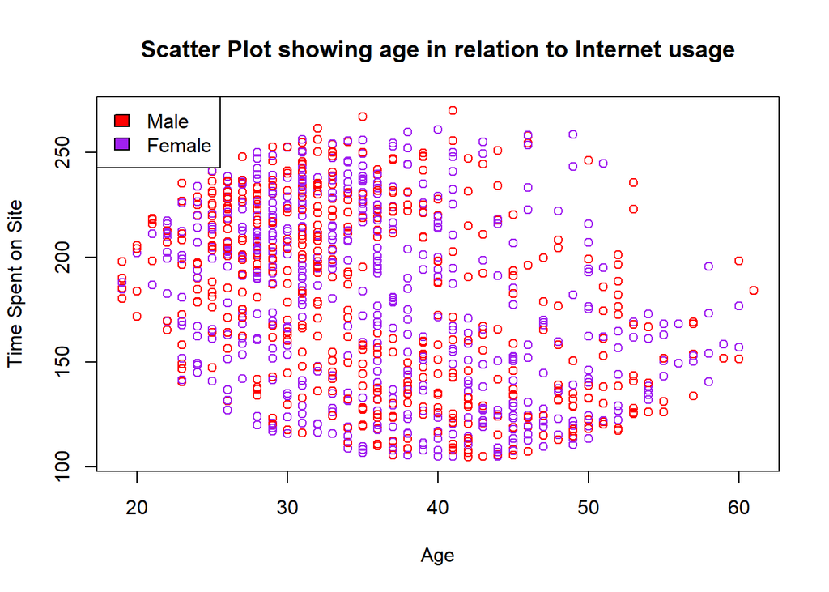

```r
# Setting a new variable
n <- advert$Daily.Internet.Usage

# Scatter plot
plot(x, n, xlab = "Age", ylab = "Time Spent on Site", col = c("red", "purple")[group1],
     main="Scatter Plot showing age in relation to Internet usage")
legend("topleft",c("Male","Female"), fill=c("red","purple"))
```